# Анализ и прогнозирование количества заказов на такси

# Содержание

Компания «Чётенькое такси» собрала исторические данные о заказах такси в аэропортах. Чтобы привлекать больше водителей в период пиковой нагрузки, нужно спрогнозировать количество заказов такси на следующий час.

**Задача:** Создать модель, которая сможет прогнозировать количество такси в следующий час.

Требование к модели: Значение метрики **RMSE** на тестовой выборке не должно превышать 48.

В рамках проекта необходимо сделать:

1. Загрузить данные и выполнить их ресемплирование по одному часовому интервалу.
2. Проанализировать данные.
3. Обучить разные модели с различными гиперпараметрами. Сделать тестовую выборку размером 10% от исходных данных.
4. Проверить данные на тестовой выборке и сделать выводы.

```python
%pip install LightGBM -q
```

```python
%pip install --upgrade scikit-learn==1.3.2 -q
%pip install --upgrade numpy==1.26.4 -q
%pip install --upgrade seaborn==0.13.0 -q
%pip install --upgrade pandas==2.1.4 -q
%pip install --upgrade scipy==1.12.0 -q
%pip install --upgrade matplotlib==3.8.0 -q
```

```python
import seaborn as sns
import pandas as pd
import matplotlib.pyplot as plt
import numpy as np
import os
from typing import Tuple

from statsmodels.tsa.seasonal import seasonal_decompose

from sklearn.model_selection import train_test_split, GridSearchCV
from sklearn.metrics import mean_squared_error
from sklearn.model_selection import TimeSeriesSplit
from sklearn.ensemble import RandomForestRegressor
from sklearn.linear_model import LinearRegression
from sklearn.tree import DecisionTreeRegressor
from sklearn.linear_model import Lasso, Ridge
from sklearn.base import BaseEstimator

from lightgbm import LGBMRegressor
```

```python
sns.set_theme()
sns.set_palette('Set2')
RANDOM_STATE = 5
TEST_SIZE = 0.1
```

## Подготовка

### Первый взгляд на данные и загрузка

```python
if os.path.exists('/datasets/taxi.csv'):
    df = pd.read_csv('/datasets/taxi.csv', parse_dates=['datetime'])
    print('Success')
elif os.path.exists('./datasets/taxi.csv'):
    df = pd.read_csv('./datasets/taxi.csv', parse_dates=['datetime'])
    print('Success')
else:
    print('Something went wrong')
```

```
Success
```

```python
df.info()
```

```
<class 'pandas.core.frame.DataFrame'>
RangeIndex: 26496 entries, 0 to 26495
Data columns (total 2 columns):
 #   Column      Non-Null Count  Dtype
---  ------      --------------  -----
 0   datetime    26496 non-null  datetime64[ns]
 1   num_orders  26496 non-null  int64
dtypes: datetime64[ns](1), int64(1)
memory usage: 414.1 KB
```

```python
df.sample(5)
```

|  | datetime | num_orders |
| --- | --- | --- |
| 14291 | 2018-06-08 05:50:00 | 4 |
| 14585 | 2018-06-10 06:50:00 | 1 |
| 6314 | 2018-04-13 20:20:00 | 23 |
| 3557 | 2018-03-25 16:50:00 | 22 |
| 8224 | 2018-04-27 02:40:00 | 12 |

### Проведем анализ количества дубликатов и пропусков

```python
def get_info(data: pd.DataFrame) -> None:
    '''
    Function for printing base information of dataframe
    :param data: dataframe for search
    '''
    print('Info about data:')
    data.info()
    print('\nInfo about missing data:\n', data.isna().sum())
    print('\nInfo about duplicates:\n', data.duplicated().sum())
```

```python
get_info(df)
```

```
Info about data:
<class 'pandas.core.frame.DataFrame'>
RangeIndex: 26496 entries, 0 to 26495
Data columns (total 2 columns):
 #   Column      Non-Null Count  Dtype
---  ------      --------------  -----
 0   datetime    26496 non-null  datetime64[ns]
 1   num_orders  26496 non-null  int64
dtypes: datetime64[ns](1), int64(1)
memory usage: 414.1 KB

Info about missing data:
 datetime      0
num_orders    0
dtype: int64

Info about duplicates:
 0
```

Отметим, что среди данных нет дубликатов и пропусков. Поскольку среди данных нет пропусков - заменим индекс датафрейма на колонку `datetime`, поскольку перед нами стоит задача прогнозирования. После этого выполним ресемплирование данных в 1 час. Как можно заметить - до этого данные были за каждые 10 минут, соответственно сумма первых 6 строчек должна быть равна первой строчке после ресемплинга

```python
df.set_index('datetime', inplace=True)
df.head(7)
```

| datetime | num_orders |
| --- | --- |
| 2018-03-01 00:00:00 | 9 |
| 2018-03-01 00:10:00 | 14 |
| 2018-03-01 00:20:00 | 28 |
| 2018-03-01 00:30:00 | 20 |
| 2018-03-01 00:40:00 | 32 |
| 2018-03-01 00:50:00 | 21 |
| 2018-03-01 01:00:00 | 7 |

```python
df.sort_index(inplace=True, ascending=True)
df = df.resample('1H').sum()
```

Выведем еще раз информацию о полученном датафрейме и данных в нем

```python
df.info()
```

```
<class 'pandas.core.frame.DataFrame'>
DatetimeIndex: 4416 entries, 2018-03-01 00:00:00 to 2018-08-31 23:00:00
Freq: H
Data columns (total 1 columns):
 #   Column      Non-Null Count  Dtype
---  ------      --------------  -----
 0   num_orders  4416 non-null   int64
dtypes: int64(1)
memory usage: 69.0 KB
```

```python
df.head(2)
```

| datetime | num_orders |
| --- | --- |
| 2018-03-01 00:00:00 | 124 |
| 2018-03-01 01:00:00 | 85 |

```python
df.tail(5)
```

| datetime | num_orders |
| --- | --- |
| 2018-08-31 19:00:00 | 136 |
| 2018-08-31 20:00:00 | 154 |
| 2018-08-31 21:00:00 | 159 |
| 2018-08-31 22:00:00 | 223 |
| 2018-08-31 23:00:00 | 205 |

Данные преобразованы верно, можно продолжить анализ и задачу прогнозирования

*Вывод*:

- Был успешно прочитан файл с данными
- Проанализированы пропуски и дубликаты: отстутствуют
- Произведена замена индекса на столбец `datetime`, сортировка индекса по возрастанию и ресемплированы данные с заменой временного промежутка на 1 час. Для анализа данные с марта до августа 2018 года включительно
- Произведена проверка правильности преобразования
- Данные успешно подготовлены к анализу

## Анализ

В качестве анализа проведем анализ тренда суммы заказа за каждый час и сезонности данных. ДЛя этого построим графики

```python
decomposed_data = seasonal_decompose(df)
```

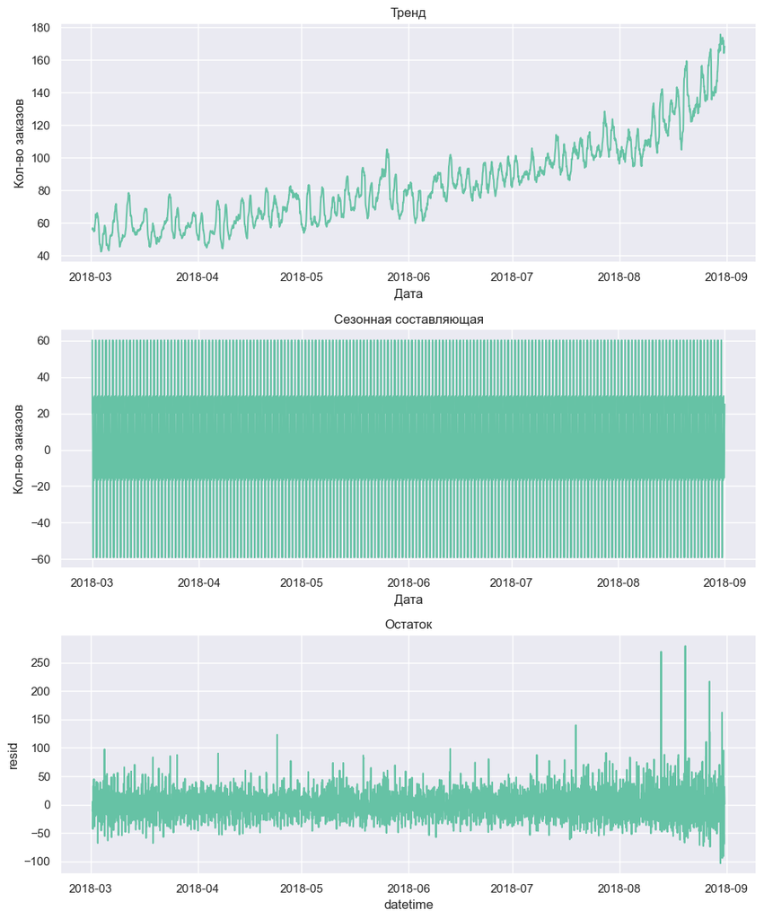

```python
fig, axs = plt.subplots(3, 1, figsize=(10, 12))

sns.lineplot(data=decomposed_data.trend, ax=axs[0])
axs[0].set_title('Тренд')

sns.lineplot(data=decomposed_data.seasonal, ax=axs[1])
axs[1].set_title('Сезонная составляющая')

sns.lineplot(data=decomposed_data.resid, ax=axs[2])
axs[2].set_title('Остаток')

for i in range(2):
    axs[i].set_ylabel('Кол-во заказов')
    axs[i].set_xlabel('Дата')
plt.tight_layout()
plt.show()
```

Рассмотрим также данные для анализа сезонности за сутки

```python
def season_plotting(timing_start: str, timing_end: str, data: pd.DataFrame) -> None:
    fig, ax = plt.subplots(figsize=(14, 8))

    sns.lineplot(data=data.seasonal[timing_start:timing_end], ax=ax, linestyle='-', linewidth=2)

    ax.set_title(f'Анализ сезонности (отрезок {timing_start}:{timing_end})')
    plt.ylabel('Кол-во заказов')
    plt.xlabel('Дата')
    plt.tight_layout()
    plt.show()
```

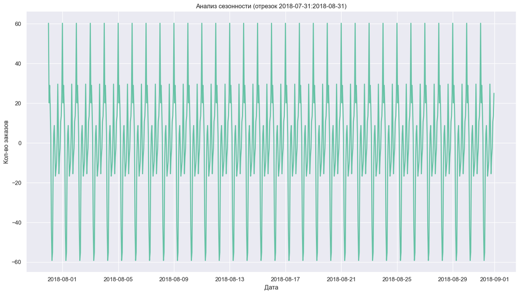

```python
season_plotting('2018-07-31','2018-08-31', decomposed_data)
```

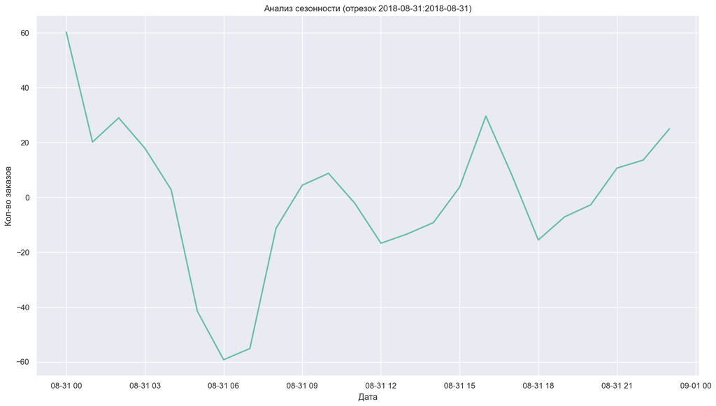

```python
season_plotting('2018-08-31','2018-08-31', decomposed_data)
```

На основе графиков можно отметить следующие ключевые моменты:

- Сезонность у данных суточная - большое количество заказов приходит на 12 часов ночи, далее кол-во заказов снижается до "начала рабочего дня" - с 6 утра идет тенденция на рост заказов до небольшого падения около 12 дня, затем новый экстремимум около 5 часов - примерное время "окончания рабочего дня", а после новый пик в 12 ночи
- Общий тренд данных - увеличение кол-ва заказов с каждым месяцем - функция тренда возрастающая. Это может быть связано как с увеличением проходимости аэропорта - большее количество самолетов, так и с длительными отпусками всей семьей - гораздо удобнее вызвать такси, чем кого-то просить забрать с аэропорта.

### Создание признаков для обучения модели

Сделаем функцию для перебора временных задержек данных и рассчитаем RMSE для оценки на линейной модели

```python
def make_features(data: pd.DataFrame, max_lag: int, rolling_mean_size: int, target: str = 'num_orders') -> pd.DataFrame:
    data_features = data.copy(deep=True)
    data_features['day'] = data_features.index.day
    data_features['dayofweek'] = data_features.index.dayofweek

    for lag in range(1, max_lag + 1):
        data_features['lag_{}'.format(lag)] = data_features[target].shift(lag)

    data_features['rolling_mean'] = data_features[target].shift().rolling(rolling_mean_size).mean()
    return data_features
```

```python
def splitting_data(data_features: pd.DataFrame, target: str = 'num_orders') -> Tuple[pd.DataFrame, pd.Series, pd.DataFrame, pd.Series]:
    train, test = train_test_split(data_features, shuffle=False, test_size=TEST_SIZE)
    train = train.dropna()
    X_train = train.drop(columns=[target])
    y_train = train[target]
    X_test = test.drop(columns=[target])
    y_test = test[target]
    return X_train, y_train, X_test, y_test
```

```python
def calcutate_rmse(data: pd.DataFrame, max_lag: int, rolling_mean_size: int, step: int = None, target: str = 'num_orders') -> pd.DataFrame:
    df_results = pd.DataFrame(columns=['lag', 'RMSE_train'])
    if not step:
        step = max_lag // 6

    for num_lag in range(0, max_lag, step):
        data_features = make_features(data, num_lag, rolling_mean_size, target)

        X_train, y_train, X_test, y_test = splitting_data(data_features)

        model = LinearRegression()
        model.fit(X_train, y_train)

        train_predict = model.predict(X_train)
        test_predict = model.predict(X_test)

        train_rmse = mean_squared_error(y_train, train_predict, squared=False)

        df_results.loc[len(df_results)] = num_lag, train_rmse

    return df_results
```

```python
calcutate_rmse(df, 50, 24, 4)
```

|  | lag | RMSE_train |
| --- | --- | --- |
| 0 | 0.0 | 34.497481 |
| 1 | 4.0 | 30.706483 |
| 2 | 8.0 | 30.615417 |
| 3 | 12.0 | 30.236570 |
| 4 | 16.0 | 29.654864 |
| 5 | 20.0 | 27.270037 |
| 6 | 24.0 | 25.947497 |
| 7 | 28.0 | 25.603328 |
| 8 | 32.0 | 25.567854 |
| 9 | 36.0 | 25.547471 |
| 10 | 40.0 | 25.429098 |
| 11 | 44.0 | 25.349827 |
| 12 | 48.0 | 23.449159 |

```python
data = make_features(df, 24, 24)
```

```python
data.head()
```

| datetime | num_orders | day | dayofweek | lag_1 | lag_2 | lag_3 | lag_4 | lag_5 | lag_6 | lag_7 | ... | lag_16 | lag_17 | lag_18 | lag_19 | lag_20 | lag_21 | lag_22 | lag_23 | lag_24 | rolling_mean |
| --- | --- | --- | --- | --- | --- | --- | --- | --- | --- | --- | --- | --- | --- | --- | --- | --- | --- | --- | --- | --- | --- |
| 2018-03-01 00:00:00 | 124 | 1 | 3 | NaN | NaN | NaN | NaN | NaN | NaN | NaN | ... | NaN | NaN | NaN | NaN | NaN | NaN | NaN | NaN | NaN | NaN |
| 2018-03-01 01:00:00 | 85 | 1 | 3 | 124.0 | NaN | NaN | NaN | NaN | NaN | NaN | ... | NaN | NaN | NaN | NaN | NaN | NaN | NaN | NaN | NaN | NaN |
| 2018-03-01 02:00:00 | 71 | 1 | 3 | 85.0 | 124.0 | NaN | NaN | NaN | NaN | NaN | ... | NaN | NaN | NaN | NaN | NaN | NaN | NaN | NaN | NaN | NaN |
| 2018-03-01 03:00:00 | 66 | 1 | 3 | 71.0 | 85.0 | 124.0 | NaN | NaN | NaN | NaN | ... | NaN | NaN | NaN | NaN | NaN | NaN | NaN | NaN | NaN | NaN |
| 2018-03-01 04:00:00 | 43 | 1 | 3 | 66.0 | 71.0 | 85.0 | 124.0 | NaN | NaN | NaN | ... | NaN | NaN | NaN | NaN | NaN | NaN | NaN | NaN | NaN | NaN |

5 rows × 28 columns

Подготовим данные для обучения - разделим на тестовую и обучающие выборки

```python
X_train, y_train, X_test, y_test = splitting_data(data)
```

## Обучение

Создадим функцию для анализа данных моделей

Предполагается использовать данные о времени обучения и метрике RMSE на кросс валидации.

В качестве моделей будем использовать линейные модели с регуляризацией, дерево решений и градиентный бустинг

```python
MODELS_RESULT = pd.DataFrame(columns=['model', 'mean_fit_time', 'params', 'mean_test_score'])
```

```python
def scoring_models(model: any, params_grid: dict, x_train: pd.DataFrame = X_train, y_train: pd.Series = y_train, result_train: pd.DataFrame = MODELS_RESULT) -> BaseEstimator:
    tscv = TimeSeriesSplit(n_splits=5)
    gs_search = GridSearchCV(model,
                             params_grid,
                             n_jobs=-1,
                             scoring='neg_root_mean_squared_error',
                             cv=tscv)
    gs_search.fit(x_train, y_train)
    results = pd.DataFrame(gs_search.cv_results_).sort_values(
        by='rank_test_score', ascending=True).head(1)
    result_train.loc[len(result_train)] = model, round(results['mean_fit_time'].values[0],
                                                       4), results['params'].values[0], round(-results['mean_test_score'].values[0], 2)

    return gs_search.best_estimator_
```

**Линейные модели**

```python
linear_ridge = Ridge(random_state=RANDOM_STATE)
params_ridge = {'solver': ['auto', 'sparse_cg', 'lsqr'],
                'alpha': np.arange(0.1, 1.0, 0.1),
                'fit_intercept': [True, False]}
ridge_model= scoring_models(linear_ridge, params_ridge)
```

```python
linear_lasso = Lasso(random_state=RANDOM_STATE)
params_lasso = {'alpha': np.arange(0.1, 1.0, 0.1),
                'tol': [0.001, 0.01, 0.1]}
lasso_model = scoring_models(linear_lasso, params_lasso)
```

**Дерево решений**

```python
tree_decision = DecisionTreeRegressor(random_state=RANDOM_STATE)
params_tree = {'max_depth': [None, 10, 20],
               'min_samples_split': [2, 10],
               'min_samples_leaf': [1, 10]}
tree_model = scoring_models(tree_decision, params_tree)
```

**Градиентный бустинг**

```python
grad_boost = LGBMRegressor(random_state=RANDOM_STATE)
params_boost = {'max_depth': [None, 10],
                'num_leaves': [31],
                'learning_rate': [0.1],
                'n_estimators': range(100, 300, 100)}
boosting_model = scoring_models(grad_boost, params_boost)
```

[output not shown]

**Случайный лес**

```python
forest = RandomForestRegressor(random_state=RANDOM_STATE)
forest_params = {'n_estimators': [200, 300],
                 'max_depth': [20],
                 'min_samples_split': [2]}
forest_model = scoring_models(forest, forest_params)
```

**Результаты**

```python
pd.set_option('display.max_colwidth', None)
MODELS_RESULT.sort_values(by='mean_test_score', ascending=True)
```

|  | model | mean_fit_time | params | mean_test_score |
| --- | --- | --- | --- | --- |
| 3 | LGBMRegressor(random_state=5) | 1.7680 | {'learning_rate': 0.1, 'max_depth': 10, 'n_estimators': 100, 'num_leaves': 31} | 25.76 |
| 4 | RandomForestRegressor(random_state=5) | 52.0857 | {'max_depth': 20, 'min_samples_split': 2, 'n_estimators': 300} | 25.79 |
| 0 | Ridge(random_state=5) | 0.0103 | {'alpha': 0.9, 'fit_intercept': False, 'solver': 'lsqr'} | 27.14 |
| 1 | Lasso(random_state=5) | 0.0120 | {'alpha': 0.8, 'tol': 0.1} | 27.17 |
| 2 | DecisionTreeRegressor(random_state=5) | 0.1463 | {'max_depth': 10, 'min_samples_leaf': 10, 'min_samples_split': 2} | 30.56 |

Моделями с лучшими результатами оказались LGBMRegressor, RandomForestRegressor, Ridge

Основываясь на обучении моделей, лучший результат на тренировочных данных показала модель LGBMRegressor

Было принято решение о представлении ее как решения для тестирования:

- Ее результат на тренировочных данных выше, чем у остальных рассматриваемых моделей
- Она обучается быстрее, чем RandomForestRegressor, чьи результаты незначительно отличаются от LGBMRegressor

## Тестирование

```python
def testing_models(model, title: str, x_test: pd.DataFrame = X_test, y_test: pd.DataFrame = y_test) -> None:
    predictions = model.predict(x_test)
    RMSE = mean_squared_error(y_test, predictions, squared=False)
    print(f'RMSE {round(RMSE, 2)} для модели {model}')
    res = pd.DataFrame({'pred': predictions,
                        'real_data': y_test})

    plt.figure(figsize=(10, 6))
    sns.scatterplot(data=res, x=res.index, y='pred', label='Предсказания')
    sns.scatterplot(data=res, x=res.index, y='real_data', label='Реальные значения')
    plt.title(title)
    plt.xlabel('Дата')
    plt.ylabel('Кол-во заказов')
    plt.tight_layout()
    plt.show()
```

```
[LightGBM] [Warning] Accuracy may be bad since you didn't explicitly set num_leaves OR 2^max_depth > num_leaves. (num_leaves=31).
RMSE 43.09 для модели LGBMRegressor(max_depth=10, random_state=5)
```

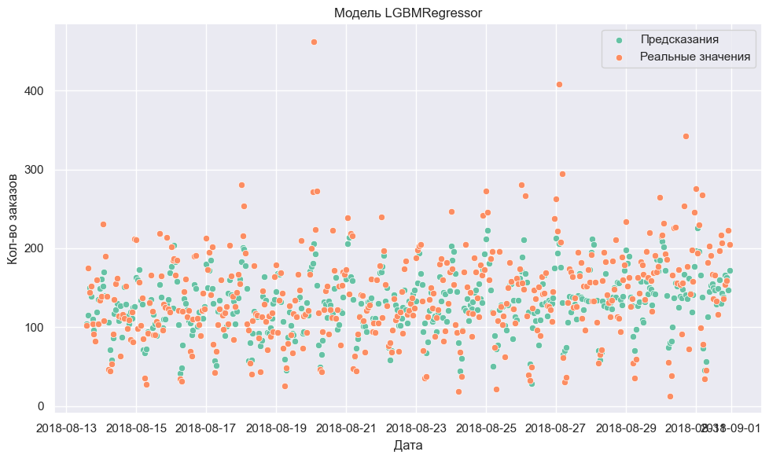

```python
testing_models(boosting_model, 'Модель LGBMRegressor')
```

Основываясь на обучении моделей, хороший результат на тестовых данных показала модель LGBMRegressor, которую выбрали дл тестирования

ее метрика RMSE на тестовых данных меньше 48, что удовлетворяет условиям отбора данных